# analisis_econometrico_NL

2026-05-28

# Librerias

```r
library(readxl)
library(dplyr)
library(tidyr)
```

```r
library(ggplot2)
library(scales)
library(patchwork)
library(corrplot)
library(car)
library(strucchange)
library(tseries)
library(urca)
library(ARDL)
library(lmtest)
library(sandwich)
library(tseries)
library(knitr)
library(reshape2)
```

# Gráficas Descriptivas

## Base

```r
# Archivo
archivo_base <- "01_base_analitica_terciarizacion.xlsx"

pib_reducido <- read_excel(archivo_base, sheet = "pib_3sectores")
```

## Tema

```r
tema_articulo <- theme_minimal(base_size = 11) +
  theme(
    plot.title = element_blank(),

    axis.title = element_text(
      size = 11,
      color = "black"
    ),

    axis.text = element_text(
      size = 10,
      color = "black"
    ),

    panel.grid.minor = element_blank(),

    panel.grid.major.x = element_blank(),

    panel.grid.major.y = element_line(
      color = "gray88",
      linewidth = 0.25
    ),

    axis.line = element_line(
      color = "black",
      linewidth = 0.3
    ),

    legend.position = "bottom",

    legend.title = element_blank(),

    legend.text = element_text(
      size = 9,
      color = "black"
    ),

    plot.margin = margin(10, 10, 10, 10)
  )
```

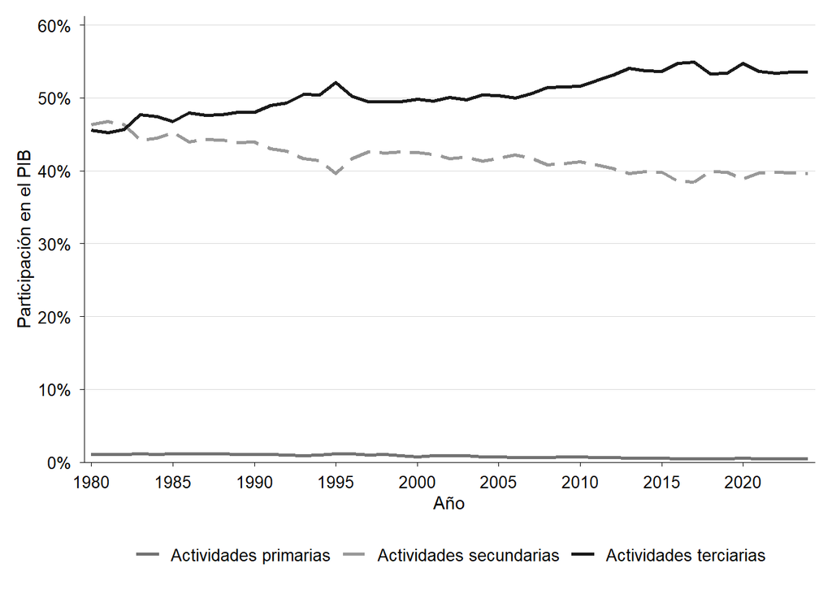

```r
# Carpeta de salida para las figuras definitivas
dir.create(
  "Figuras_Revista",
  showWarnings = FALSE,
  recursive = TRUE
)

# Base en formato largo
datos_largos_fig1 <- pib_reducido %>%
  pivot_longer(
    cols = c(
      `actividades primarias`,
      `actividades secundarias`,
      `actividades terciarias`
    ),
    names_to = "sector",
    values_to = "participacion"
  ) %>%
  mutate(
    sector = factor(
      sector,
      levels = c(
        "actividades primarias",
        "actividades secundarias",
        "actividades terciarias"
      ),
      labels = c(
        "Actividades primarias",
        "Actividades secundarias",
        "Actividades terciarias"
      )
    )
  )

# Paleta en escala de grises
colores_grises_fig1 <- c(
  "Actividades primarias" = "gray45",
  "Actividades secundarias" = "gray60",
  "Actividades terciarias" = "gray10"
)

# Tipos de línea para mejorar lectura en blanco y negro
tipos_linea_fig1 <- c(
  "Actividades primarias" = "solid",
  "Actividades secundarias" = "longdash",
  "Actividades terciarias" = "solid"
)

# Tema editorial uniforme
tema_revista <- theme_minimal(base_size = 11) +
  theme(
    plot.title = element_blank(),
    axis.title = element_text(size = 11, color = "black"),
    axis.text = element_text(size = 10, color = "black"),
    legend.position = "bottom",
    legend.title = element_blank(),
    legend.text = element_text(size = 10, color = "black"),
    panel.grid.minor = element_blank(),
    panel.grid.major.x = element_blank(),
    panel.grid.major.y = element_line(color = "gray85", linewidth = 0.3),
    axis.line = element_line(color = "black", linewidth = 0.3),
    axis.ticks = element_line(color = "black", linewidth = 0.3),
    plot.margin = margin(10, 10, 10, 10)
  )

# Objeto final de la figura
g_figura_1 <- ggplot(
  datos_largos_fig1,
  aes(
    x = año,
    y = participacion,
    color = sector,
    linetype = sector
  )
) +
  geom_line(linewidth = 1) +
  scale_color_manual(values = colores_grises_fig1) +
  scale_linetype_manual(values = tipos_linea_fig1) +
  scale_y_continuous(
    labels = percent_format(accuracy = 1),
    breaks = seq(0, 0.6, 0.1),
    limits = c(0, 0.6),
    expand = expansion(mult = c(0, 0.02))
  ) +
  scale_x_continuous(
    breaks = seq(1980, 2025, 5),
    expand = expansion(mult = c(0.01, 0.01))
  ) +
  labs(
    x = "Año",
    y = "Participación en el PIB"
  ) +
  tema_revista

# Mostrar figura
g_figura_1
```

```r
ggsave(
  filename = "Figuras_Revista/Figura_1_Participacion_sectorial_PIB_NL.tiff",
  plot = g_figura_1,
  width = 16,
  height = 10,
  units = "cm",
  dpi = 300,
  compression = "lzw",
  bg = "white"
)
```

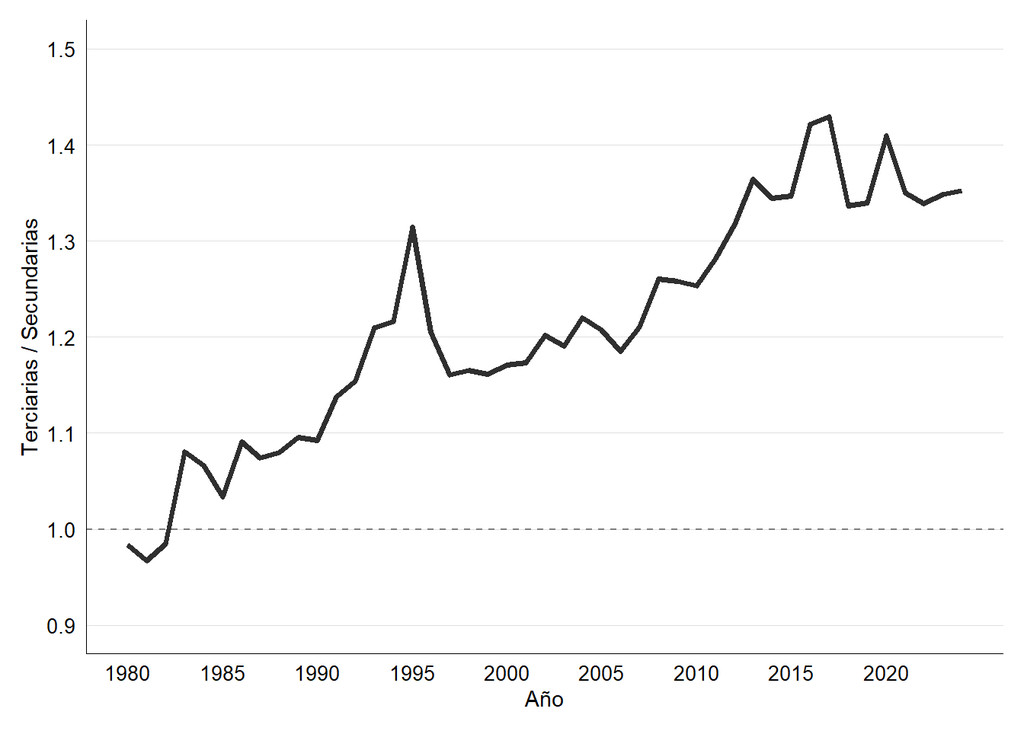

```r
# Índice de terciarización
# Actividades terciarias / actividades secundarias

pib_reducido <- pib_reducido %>%
  mutate(
    indice_terciarizacion =
      `actividades terciarias` /
      `actividades secundarias`
  )

ggplot(
  pib_reducido,
  aes(
    x = año,
    y = indice_terciarizacion
  )
) +

  geom_line(
    linewidth = 1.3,
    color = "#2F2F2F"
  ) +

  geom_hline(
    yintercept = 1,
    linetype = "dashed",
    linewidth = 0.5,
    color = "gray50"
  ) +

  scale_y_continuous(
    limits = c(0.9, 1.5),
    breaks = seq(0.9, 1.5, 0.1)
  ) +

  scale_x_continuous(
    breaks = seq(1980, 2024, 5)
  ) +

  labs(
    x = "Año",
    y = "Terciarias / Secundarias"
  ) +

  tema_articulo
```

```r
pib_terc <- read_excel(archivo_base, sheet = "pib_terc")
```

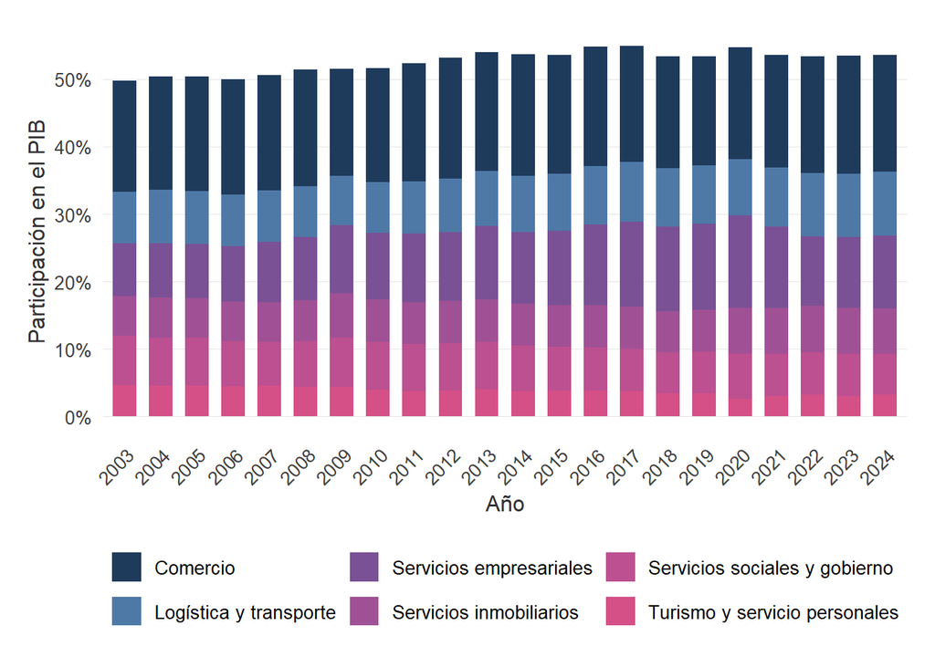

```r
# Convertir a formato largo
datos_largos <- pib_terc %>%
  pivot_longer(
    cols = -Año,
    names_to = "sector",
    values_to = "participacion"
  )

# Colores estilo paper
colores <- c(
  "Comercio" = "#1F3B5C",
  "Logística y transporte" = "#4E79A7",
  "Servicios empresariales" = "#7A5195",
  "Servicios inmobiliarios" = "#A05195",
  "Servicios sociales y gobierno" = "#BC5090",
  "Turismo y servicio personales" = "#D45087"
)

# Tema minimalista profesional
tema_articulo <- theme_minimal(base_size = 13) +
  theme(

    plot.title = element_blank(),

    axis.title = element_text(
      size = 12,
      color = "gray20"
    ),

    axis.text = element_text(
      size = 10,
      color = "gray25"
    ),

    panel.grid.minor = element_blank(),

    panel.grid.major.x = element_blank(),

    panel.grid.major.y = element_line(
      color = "gray90",
      linewidth = 0.25
    ),

    legend.position = "bottom",

    legend.title = element_blank(),

    legend.text = element_text(size = 10),

    legend.justification = "center",

    plot.margin = margin(15, 15, 15, 15)
  )

# Gráfica de barras apiladas
ggplot(
  datos_largos,
  aes(
    x = factor(Año),
    y = participacion,
    fill = sector
  )
) +

  geom_col(
    width = 0.65
  ) +

  scale_fill_manual(
    values = colores
  ) +

  scale_y_continuous(
    labels = percent_format(accuracy = 1),
    breaks = seq(0, 0.7, 0.1)
  ) +

  labs(
    x = "Año",
    y = "Participación en el PIB"
  ) +

  tema_articulo +

  theme(
    axis.text.x = element_text(
      angle = 45,
      hjust = 1
    )
  )
```

```r
pib_sec <- read_excel(archivo_base, sheet = "pib_sec")
```

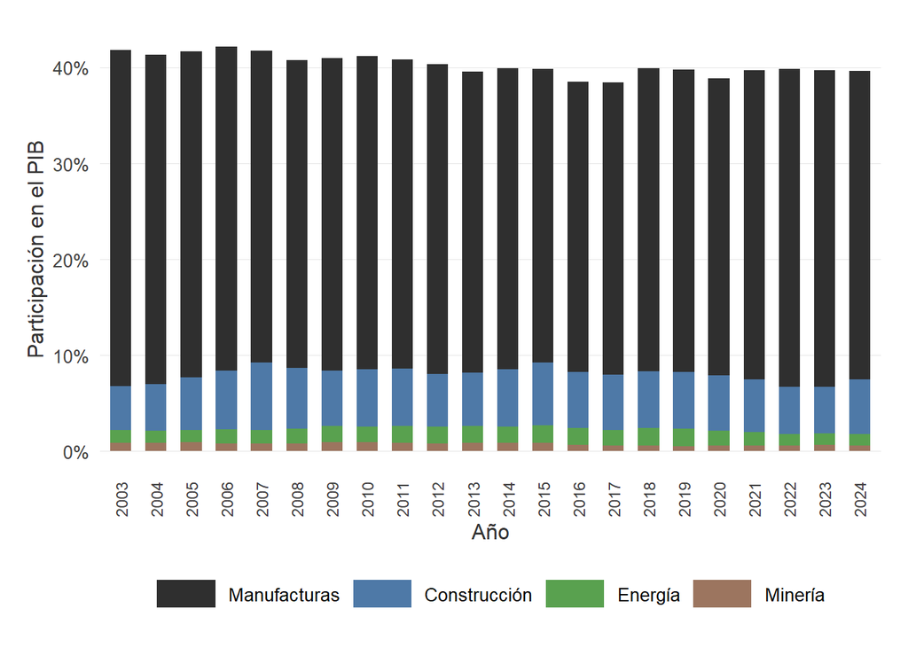

```r
# Renombrar variables para una leyenda limpia
pib_sec_graf <- pib_sec %>%
  rename(
    Energía = `Generación, transmisión, distribución y comercialización de energía eléctrica, suministro de agua y de gas natural por ductos al consumidor final`,
    Manufacturas = `Industrias manufactureras`
  )

# Formato largo
datos_largos <- pib_sec_graf %>%
  pivot_longer(
    cols = -Año,
    names_to = "sector",
    values_to = "participacion"
  )

# Orden de aparición en la leyenda
datos_largos$sector <- factor(
  datos_largos$sector,
  levels = c(
    "Manufacturas",
    "Construcción",
    "Energía",
    "Minería"
  )
)

# Colores (manteniendo tu paleta)
colores <- c(
  "Manufacturas" = "#2F2F2F",
  "Construcción" = "#4E79A7",
  "Energía" = "#59A14F",
  "Minería" = "#9C755F"
)

# Gráfica
ggplot(
  datos_largos,
  aes(
    x = factor(Año),
    y = participacion,
    fill = sector
  )
) +

  geom_col(
    width = 0.60
  ) +

  scale_fill_manual(
    values = colores
  ) +

  scale_y_continuous(
    labels = percent_format(accuracy = 1),
    breaks = seq(0, 0.5, 0.1)
  ) +

  labs(
    x = "Año",
    y = "Participación en el PIB"
  ) +

  tema_articulo +

  theme(

    axis.text.x = element_text(
      angle = 90,
      vjust = 0.5,
      size = 9
    ),

    legend.position = "bottom",

    legend.title = element_blank(),

    legend.text = element_text(
      size = 10
    ),

    legend.key.width = unit(1.2, "cm")

  )
```

# MODELO ECONOMÉTRICO. CAMBIO ESTRUCTURAL Y TERCIARIZACIÓN EN NUEVO LEÓN

## Base de datos

```r
base_final <- read_excel(archivo_base, sheet = "base_nl")
```

```r
# Contar valores faltantes por variable

colSums(is.na(base_final))
```

```
##           año          terc    per_capita poblacion_urb           ied
##             0             0             0             0            19
##   escolaridad exportaciones
##             0            27
```

```r
# Verificar periodo cubierto por la base

range(base_final$año)
```

```
## [1] 1980 2024
```

## 2. TRANSFORMACIÓN DE VARIABLES

```r
# Crear logaritmo natural del ingreso per cápita.
# Facilita la interpretación económica y reduce problemas de escala.

base_final$ln_per_capita <- log(base_final$per_capita)

# Crear logaritmo natural de la IED.
# Los valores NA se conservarán automáticamente.

base_final$ln_ied <- log(base_final$ied)
```

## 3. ESTADÍSTICA DESCRIPTIVA

```r
# Resumen estadístico
summary(base_final)
```

```
##       año            terc          per_capita     poblacion_urb
##  Min.   :1980   Min.   :0.4523   Min.   :226283   Min.   :0.8744
##  1st Qu.:1991   1st Qu.:0.4895   1st Qu.:247781   1st Qu.:0.9219
##  Median :2002   Median :0.5035   Median :304089   Median :0.9379
##  Mean   :2002   Mean   :0.5056   Mean   :288692   Mean   :0.9326
##  3rd Qu.:2013   3rd Qu.:0.5334   3rd Qu.:321101   3rd Qu.:0.9504
##  Max.   :2024   Max.   :0.5492   Max.   :341831   Max.   :0.9636
##
##       ied        escolaridad     exportaciones    ln_per_capita
##  Min.   :1076   Min.   : 6.000   Min.   :0.2417   Min.   :12.33
##  1st Qu.:1923   1st Qu.: 8.084   1st Qu.:0.2792   1st Qu.:12.42
##  Median :3065   Median : 9.034   Median :0.3544   Median :12.63
##  Mean   :2928   Mean   : 8.913   Mean   :0.3418   Mean   :12.56
##  3rd Qu.:3447   3rd Qu.:10.000   3rd Qu.:0.3973   3rd Qu.:12.68
##  Max.   :5930   Max.   :10.915   Max.   :0.4558   Max.   :12.74
##  NA's   :19                      NA's   :27
##      ln_ied
##  Min.   :6.981
##  1st Qu.:7.561
##  Median :8.028
##  Mean   :7.903
##  3rd Qu.:8.145
##  Max.   :8.688
##  NA's   :19
```

```r
tabla_resumen <- data.frame(
  Variable = names(base_final)[-1],
  Media = sapply(base_final[-1], mean, na.rm = TRUE),
  `Desv. Est.` = sapply(base_final[-1], sd, na.rm = TRUE),
  Min = sapply(base_final[-1], min, na.rm = TRUE),
  Max = sapply(base_final[-1], max, na.rm = TRUE),
  row.names = NULL,
  check.names = FALSE
)

tabla_resumen[, -1] <- round(tabla_resumen[, -1], 2)

tabla_resumen
```

```
##        Variable     Media Desv. Est.       Min       Max
## 1          terc      0.51       0.03      0.45      0.55
## 2    per_capita 288692.27   38447.61 226283.00 341831.00
## 3 poblacion_urb      0.93       0.02      0.87      0.96
## 4           ied   2928.20    1179.22   1075.70   5929.55
## 5   escolaridad      8.91       1.38      6.00     10.91
## 6 exportaciones      0.34       0.07      0.24      0.46
## 7 ln_per_capita     12.56       0.14     12.33     12.74
## 8        ln_ied      7.90       0.41      6.98      8.69
```

## 4. ANÁLISIS GRÁFICO DE LAS SERIES

```r
tema_articulo <- theme_minimal(base_size = 13) +
  theme(

    plot.title = element_blank(),

    axis.title = element_text(
      size = 12,
      color = "gray20"
    ),

    axis.text = element_text(
      size = 11,
      color = "gray25"
    ),

    panel.grid.minor = element_blank(),

    panel.grid.major.x = element_blank(),

    panel.grid.major.y = element_line(
      color = "gray90",
      linewidth = 0.25
    ),

    legend.position = "none",

    plot.margin = margin(15, 15, 15, 15)
  )
```

### Gráfica 1. Terciariazación.

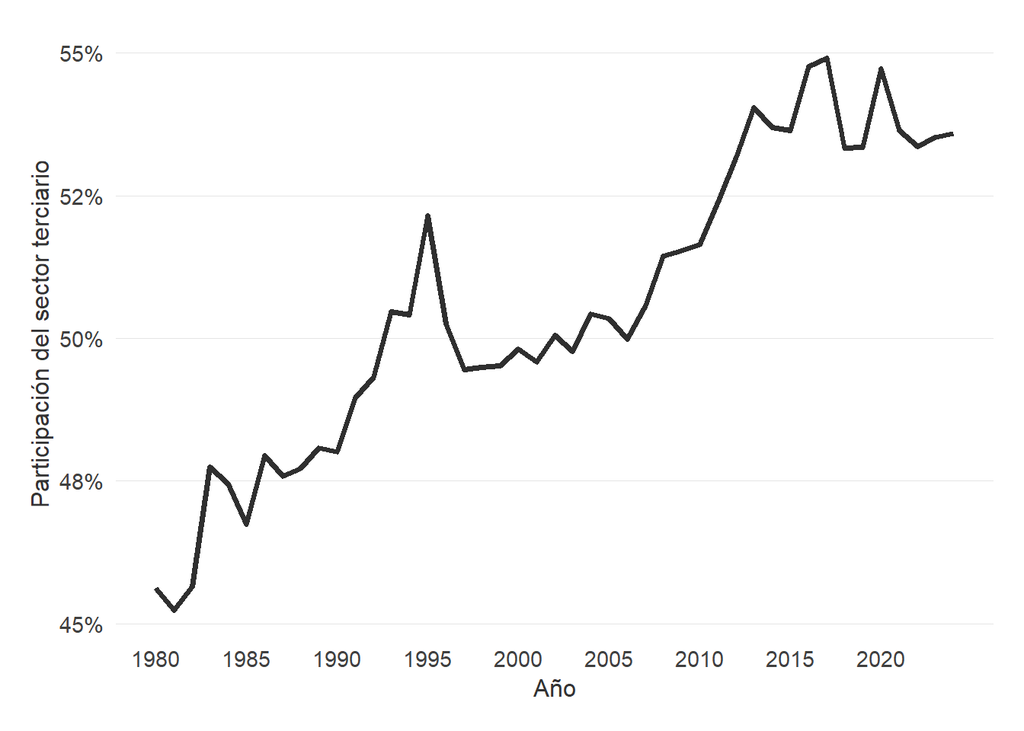

```r
g_terc <- ggplot(
  base_final,
  aes(
    x = año,
    y = terc
  )
) +

  geom_line(
    linewidth = 1.3,
    color = "#2F2F2F"
  ) +

  scale_y_continuous(
    labels = percent_format(accuracy = 1)
  ) +

  scale_x_continuous(
    breaks = seq(1980, 2024, 5)
  ) +

  labs(
    x = "Año",
    y = "Participación del sector terciario"
  ) +

  tema_articulo

g_terc
```

### Gráfica 2. PIB per cápita.

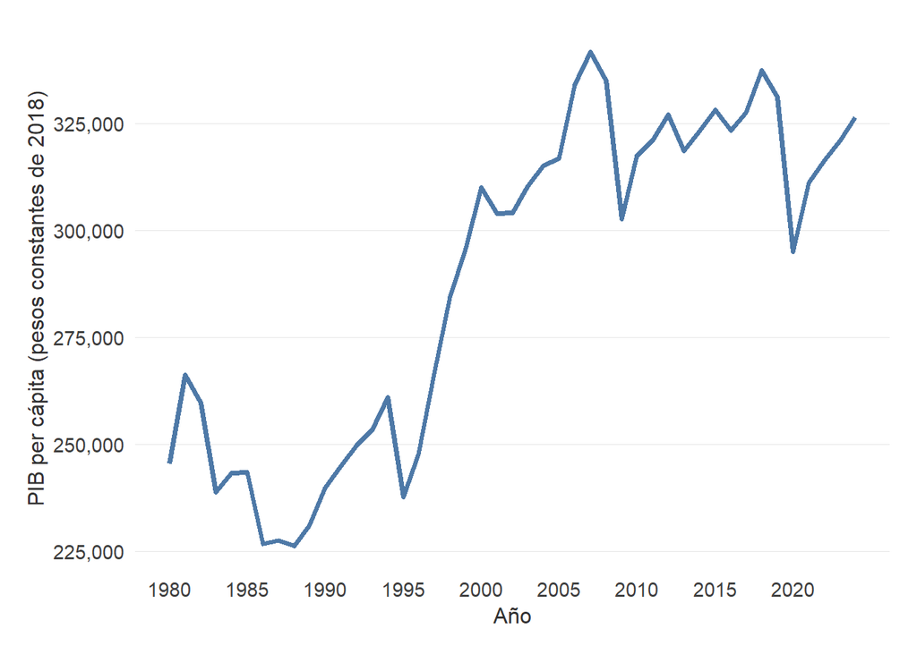

```r
g_percapita <- ggplot(
  base_final,
  aes(
    x = año,
    y = per_capita
  )
) +

  geom_line(
    linewidth = 1.3,
    color = "#4E79A7"
  ) +

  scale_y_continuous(
    labels = label_number(
      big.mark = ",",
      decimal.mark = "."
    )
  ) +

  scale_x_continuous(
    breaks = seq(1980, 2024, 5)
  ) +

  labs(
    x = "Año",
    y = "PIB per cápita (pesos constantes de 2018)"
  ) +

  tema_articulo

g_percapita
```

### Gráfica 3. Urbanización.

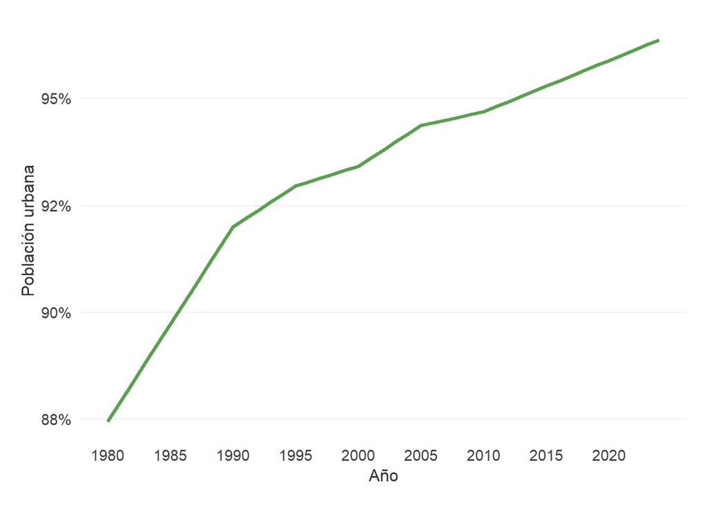

```r
g_urb <- ggplot(
  base_final,
  aes(
    x = año,
    y = poblacion_urb
  )
) +

  geom_line(
    linewidth = 1.3,
    color = "#59A14F"
  ) +

  scale_y_continuous(
    labels = percent_format(accuracy = 1)
  ) +

  scale_x_continuous(
    breaks = seq(1980, 2024, 5)
  ) +

  labs(
    x = "Año",
    y = "Población urbana"
  ) +

  tema_articulo

g_urb
```

### Gráfica 4. Escolaridad

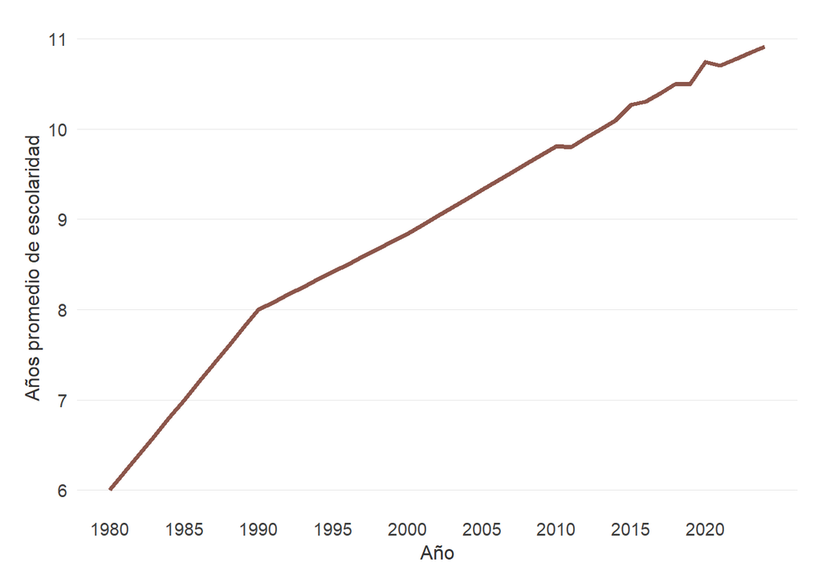

```r
g_esc <- ggplot(
  base_final,
  aes(
    x = año,
    y = escolaridad
  )
) +

  geom_line(
    linewidth = 1.3,
    color = "#8C564B"
  ) +

  scale_x_continuous(
    breaks = seq(1980, 2024, 5)
  ) +

  labs(
    x = "Año",
    y = "Años promedio de escolaridad"
  ) +

  tema_articulo

g_esc
```

### Gráfica 5. IED

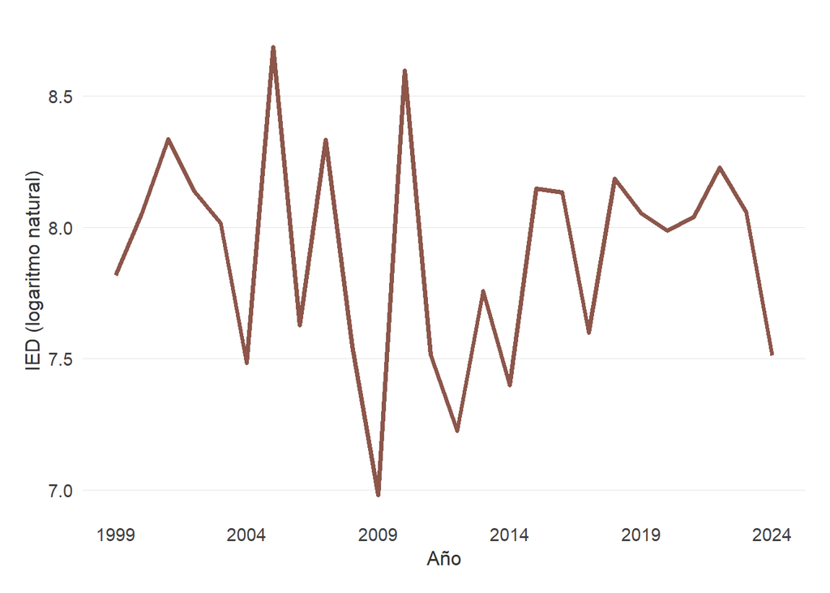

```r
g_ied <- ggplot(
  filter(base_final, año >= 1999),
  aes(
    x = año,
    y = ln_ied
  )
) +

  geom_line(
    linewidth = 1.3,
    color = "#8C564B"
  ) +

  scale_x_continuous(
    breaks = seq(1999, 2024, 5)
  ) +

  labs(
    x = "Año",
    y = "IED (logaritmo natural)"
  ) +

  tema_articulo

g_ied
```

### Gráfica 6. Exportaciones

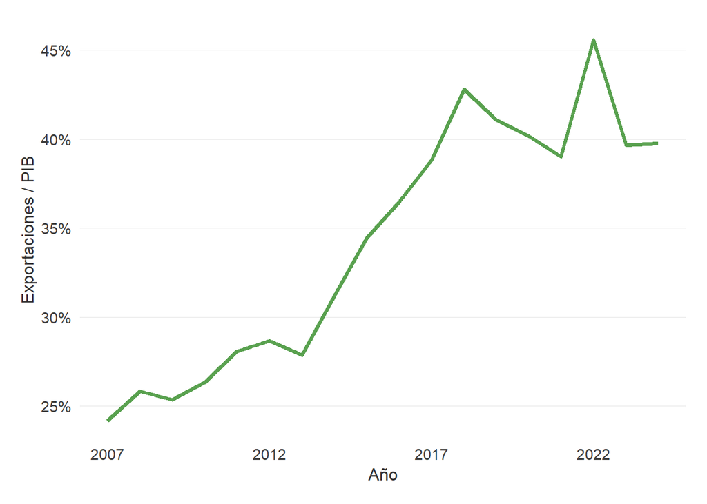

```r
g_export <- ggplot(
  filter(base_final, año >= 2007),
  aes(
    x = año,
    y = exportaciones
  )
) +

  geom_line(
    linewidth = 1.3,
    color = "#59A14F"
  ) +

  scale_y_continuous(
    labels = percent_format(
      accuracy = 1
    )
  ) +

  scale_x_continuous(
    breaks = seq(2007, 2024, 5)
  ) +

  labs(
    x = "Año",
    y = "Exportaciones / PIB"
  ) +

  tema_articulo

g_export
```

## 5. MATRIZ DE CORRELACIONES

```r
# Seleccionar únicamente las variables del modelo

corr_base <- base_final %>%
  select(
    terc,
    ln_per_capita,
    poblacion_urb,
    escolaridad,
    ln_ied,
    exportaciones
  )
```

```r
# Calcular matriz de correlaciones

matriz_cor <- cor(
  corr_base,
  use = "complete.obs",
  method = "pearson"
)

matriz_cor
```

```
##                       terc ln_per_capita poblacion_urb escolaridad      ln_ied
## terc           1.000000000   -0.26391232     0.6609969   0.7038180 0.005453975
## ln_per_capita -0.263912320    1.00000000    -0.1985689  -0.2486125 0.166605522
## poblacion_urb  0.660996887   -0.19856887     1.0000000   0.9931421 0.223244469
## escolaridad    0.703817965   -0.24861252     0.9931421   1.0000000 0.244526072
## ln_ied         0.005453975    0.16660552     0.2232445   0.2445261 1.000000000
## exportaciones  0.672946733   -0.09881673     0.9249799   0.9364849 0.318444197
##               exportaciones
## terc             0.67294673
## ln_per_capita   -0.09881673
## poblacion_urb    0.92497995
## escolaridad      0.93648487
## ln_ied           0.31844420
## exportaciones    1.00000000
```

```r
kable(
  matriz_cor,
  digits = 2,
  caption = "Matriz de correlaciones de Pearson"
)
```

Matriz de correlaciones de Pearson

|  | terc | ln_per_capita | poblacion_urb | escolaridad | ln_ied | exportaciones |
| --- | --- | --- | --- | --- | --- | --- |
| terc | 1.00 | -0.26 | 0.66 | 0.70 | 0.01 | 0.67 |
| ln_per_capita | -0.26 | 1.00 | -0.20 | -0.25 | 0.17 | -0.10 |
| poblacion_urb | 0.66 | -0.20 | 1.00 | 0.99 | 0.22 | 0.92 |
| escolaridad | 0.70 | -0.25 | 0.99 | 1.00 | 0.24 | 0.94 |
| ln_ied | 0.01 | 0.17 | 0.22 | 0.24 | 1.00 | 0.32 |
| exportaciones | 0.67 | -0.10 | 0.92 | 0.94 | 0.32 | 1.00 |

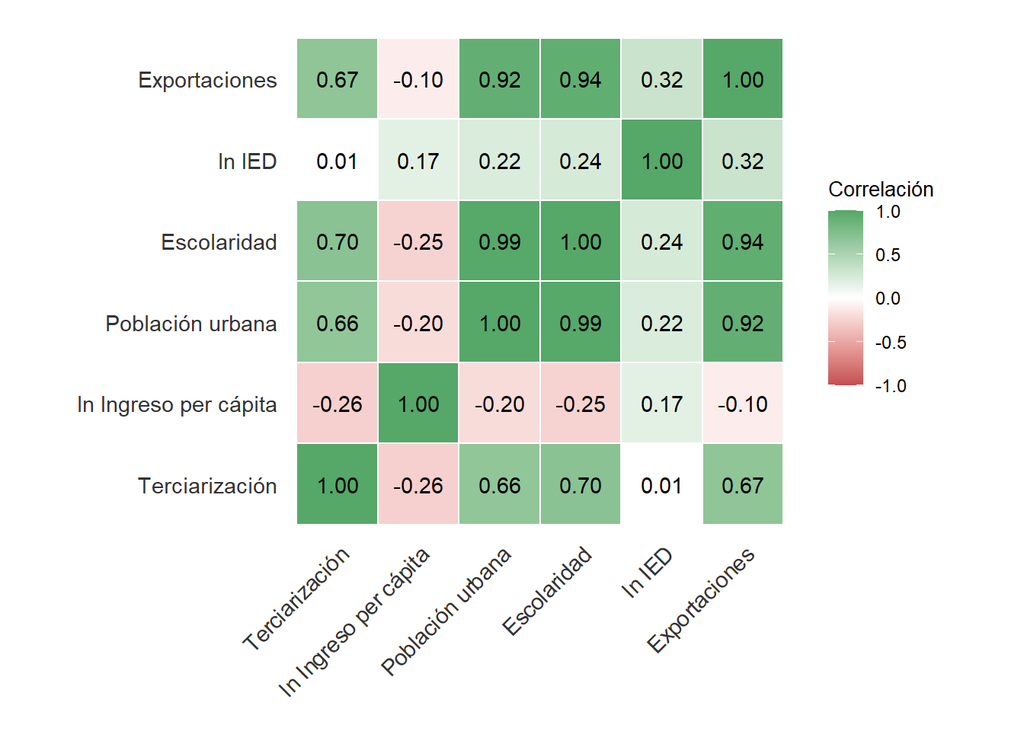

```r
cor_long <- melt(matriz_cor)

cor_long$Var1 <- factor(
  cor_long$Var1,
  levels = c(
    "terc",
    "ln_per_capita",
    "poblacion_urb",
    "escolaridad",
    "ln_ied",
    "exportaciones"
  ),
  labels = c(
    "Terciarización",
    "ln Ingreso per cápita",
    "Población urbana",
    "Escolaridad",
    "ln IED",
    "Exportaciones"
  )
)

cor_long$Var2 <- factor(
  cor_long$Var2,
  levels = c(
    "terc",
    "ln_per_capita",
    "poblacion_urb",
    "escolaridad",
    "ln_ied",
    "exportaciones"
  ),
  labels = c(
    "Terciarización",
    "ln Ingreso per cápita",
    "Población urbana",
    "Escolaridad",
    "ln IED",
    "Exportaciones"
  )
)

ggplot(
  cor_long,
  aes(
    x = Var1,
    y = Var2,
    fill = value
  )
) +

  geom_tile(
    color = "white",
    linewidth = 0.4
  ) +

  geom_text(
    aes(
      label = sprintf("%.2f", value)
    ),
    size = 3.8,
    color = "black"
  ) +

  scale_fill_gradient2(
    low = "#C44E52",
    mid = "white",
    high = "#55A868",
    midpoint = 0,
    limits = c(-1, 1),
    name = "Correlación"
  ) +

  coord_fixed() +

  labs(
    x = NULL,
    y = NULL
  ) +

  theme_minimal(base_size = 12) +

  theme(

    panel.grid = element_blank(),

    axis.text.x = element_text(
      angle = 45,
      hjust = 1,
      size = 11,
      color = "gray20"
    ),

    axis.text.y = element_text(
      size = 11,
      color = "gray20"
    ),

    legend.position = "right",

    legend.title = element_text(
      size = 10
    ),

    legend.text = element_text(
      size = 9
    ),

    plot.margin = margin(
      15, 15, 15, 15
    )
  )
```

## 6. MULTICOLINEALIDAD (VIF)

```r
modelo_vif <- lm(
  terc ~ ln_per_capita + poblacion_urb + escolaridad + ln_ied + exportaciones,
  data = base_final
)

vif(modelo_vif)
```

```
## ln_per_capita poblacion_urb   escolaridad        ln_ied exportaciones
##      1.877083    110.163228    146.328008      1.263708     11.072285
```

El análisis VIF de la especificación ampliada muestra evidencia de multicolinealidad elevada. En particular, población urbana y escolaridad presentan valores muy superiores al umbral de referencia de 10, lo que indica una fuerte relación lineal entre ambas variables. Asimismo, exportaciones registra un VIF ligeramente superior a 10, por lo que también debe interpretarse con cautela. En contraste, ln_per_capita e ln_ied presentan valores bajos, por lo que no muestran problemas relevantes de multicolinealidad.

```r
modelo_vif_principal <- lm(
  terc ~ ln_per_capita + escolaridad,
  data = base_final
)

vif(modelo_vif_principal)
```

```
## ln_per_capita   escolaridad
##      3.199165      3.199165
```

El análisis VIF del modelo principal muestra valores de 3.20 para ln_per_capita y escolaridad. Dado que estos valores se encuentran por debajo del umbral de referencia de 10, no se identifica un problema severo de multicolinealidad entre ambas variables explicativas. Esto sugiere que, aunque existe cierta relación entre ingreso per cápita y escolaridad, esta no es lo suficientemente alta como para comprometer de forma importante la estimación del modelo.

```r
modelo_vif_complementario <- lm(
  terc ~ ln_ied + exportaciones,
  data = base_final
)

vif(modelo_vif_complementario)
```

```
##        ln_ied exportaciones
##      1.112851      1.112851
```

El análisis VIF del modelo complementario muestra valores de 1.11 para ln_ied y exportaciones. Dado que estos valores se encuentran muy por debajo del umbral de referencia de 10, no se identifica un problema de multicolinealidad entre ambas variables explicativas. Esto sugiere que la inversión extranjera directa y las exportaciones no presentan una relación lineal lo suficientemente alta como para afectar la estimación del modelo.

## 7. PRUEBA DE CAMBIO ESTRUCTURAL

### Prueba de cambio estructural

H0: No existen cambios estructurales H1: Existe al menos un cambio estructural

```r
sctest(
  terc ~ 1,
  type = "supF",
  data = base_final
)
```

```
##
##  supF test
##
## data:  terc ~ 1
## sup.F = 94.17, p-value < 2.2e-16
```

Se rechaza H0. Existe evidencia estadísticamente significativa de al menos una ruptura estructural en la trayectoria de la participación del sector terciario de Nuevo León.

### (BAI-PERRON)

```r
bp_terc <- breakpoints(
  terc ~ 1,
  data = base_final
)

summary(bp_terc)
```

```
##
##   Optimal (m+1)-segment partition:
##
## Call:
## breakpoints.formula(formula = terc ~ 1, data = base_final)
##
## Breakpoints at observation number:
##
## m = 1           28
## m = 2     11       31
## m = 3   6 12       31
## m = 4   6 12    27 33
## m = 5   6 12 18 27 33
## m = 6   6 12 18 27 33 39
##
## Corresponding to breakdates:
##
## m = 1                                           0.622222222222222
## m = 2                     0.244444444444444
## m = 3   0.133333333333333 0.266666666666667
## m = 4   0.133333333333333 0.266666666666667     0.6
## m = 5   0.133333333333333 0.266666666666667 0.4 0.6
## m = 6   0.133333333333333 0.266666666666667 0.4 0.6
##
## m = 1
## m = 2   0.688888888888889
## m = 3   0.688888888888889
## m = 4   0.733333333333333
## m = 5   0.733333333333333
## m = 6   0.733333333333333 0.866666666666667
##
## Fit:
##
## m   0          1          2          3          4          5
## RSS  3.078e-02  9.649e-03  3.175e-03  2.514e-03  2.122e-03  2.048e-03
## BIC -1.926e+02 -2.372e+02 -2.796e+02 -2.825e+02 -2.825e+02 -2.765e+02
##
## m   6
## RSS  2.007e-03
## BIC -2.698e+02
```

```r
# Permite identificar el rango de años donde
# probablemente ocurrió cada cambio estructural.

confint(bp_terc)
```

```
##
##   Confidence intervals for breakpoints
##   of optimal 5-segment partition:
##
## Call:
## confint.breakpointsfull(object = bp_terc)
##
## Breakpoints at observation number:
##   2.5 % breakpoints 97.5 %
## 1     5           6     11
## 2    10          12     13
## 3    24          27     29
## 4    32          33     35
##
## Corresponding to breakdates:
```

```
##       2.5 % breakpoints    97.5 %
## 1 0.1111111   0.1333333 0.2444444
## 2 0.2222222   0.2666667 0.2888889
## 3 0.5333333   0.6000000 0.6444444
## 4 0.7111111   0.7333333 0.7777778
```

```r
breakpoints(bp_terc)
```

```
##
##   Optimal 5-segment partition:
##
## Call:
## breakpoints.breakpointsfull(obj = bp_terc)
##
## Breakpoints at observation number:
## 6 12 27 33
##
## Corresponding to breakdates:
## 0.1333333 0.2666667 0.6 0.7333333
```

```r
bp_terc$breakpoints
```

```
## [1]  6 12 27 33
```

La prueba de Bai-Perron sugiere la presencia de múltiples cambios estructurales en la trayectoria de la participación del sector terciario en Nuevo León. De acuerdo con el criterio BIC, los modelos con tres y cuatro rupturas presentan el mejor ajuste, identificándose posibles puntos de cambio alrededor de los años 1985, 1991, 2006 y 2012. Estos resultados constituyen evidencia preliminar de que el proceso de terciarización no siguió una trayectoria homogénea durante el periodo analizado.

La prueba supF rechaza la hipótesis nula de ausencia de cambios estructurales (F = 94.17; p < 0.001), lo que confirma la existencia de rupturas significativas en la trayectoria de la participación del sector terciario en Nuevo León. De acuerdo con la prueba de Bai-Perron, los principales puntos de cambio se ubican aproximadamente en 1985, 1991, 2006 y 2012, sugiriendo que el proceso de terciarización atravesó distintas etapas asociadas a transformaciones económicas y productivas de largo plazo.

El proceso de terciarización de Nuevo León no siguió una trayectoria homogénea, sino que presentó cambios estructurales asociados a distintas etapas de transformación económica.

## Terciarización

```r
periodos_terc <- tibble::tibble(
  periodo = factor(
    c(
      "1980–1985",
      "1986–1991",
      "1992–2006",
      "2007–2012",
      "2013–2024"
    ),
    levels = c(
      "1980–1985",
      "1986–1991",
      "1992–2006",
      "2007–2012",
      "2013–2024"
    )
  ),
  inicio = c(1980, 1986, 1992, 2007, 2013),
  fin = c(1985, 1991, 2006, 2012, 2024)
)
```

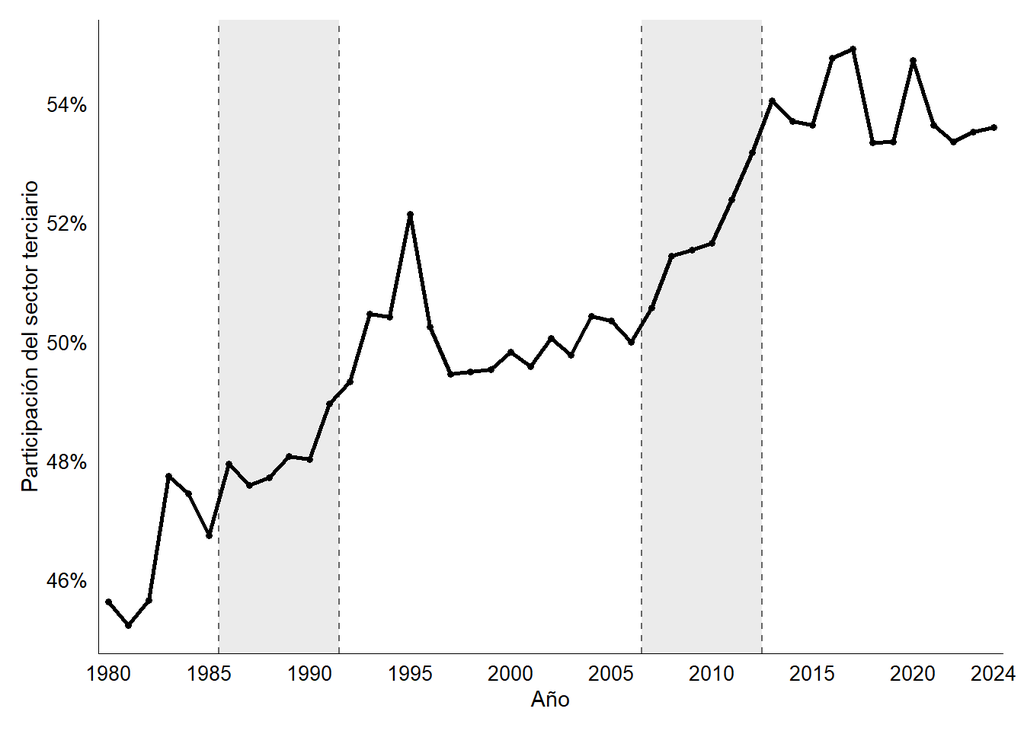

```r
# Gráfica 3. Participación terciaria y quiebres estructurales

g_terc_periodos <- ggplot() +

  geom_rect(
    data = periodos_terc,
    aes(
      xmin = inicio - 0.5,
      xmax = fin + 0.5,
      ymin = -Inf,
      ymax = Inf,
      fill = periodo
    ),
    inherit.aes = FALSE
  ) +

  geom_vline(
    xintercept = c(1985.5, 1991.5, 2006.5, 2012.5),
    linetype = "dashed",
    linewidth = 0.5,
    color = "gray40"
  ) +

  geom_line(
    data = base_final,
    aes(x = año, y = terc),
    linewidth = 1,
    color = "black"
  ) +

  geom_point(
    data = base_final,
    aes(x = año, y = terc),
    size = 1.3,
    color = "black"
  ) +

  scale_fill_manual(
    values = c(
      "1980–1985" = "white",
      "1986–1991" = "gray92",
      "1992–2006" = "white",
      "2007–2012" = "gray92",
      "2013–2024" = "white"
    ),
    guide = "none"
  ) +

  scale_y_continuous(
    labels = percent_format(accuracy = 1),
    breaks = seq(0.40, 0.60, 0.02)
  ) +

  scale_x_continuous(
    breaks = c(
      1980, 1985, 1990, 1995, 2000,
      2005, 2010, 2015, 2020, 2024
    ),
    limits = c(1979.5, 2024.5),
    expand = c(0, 0)
  ) +

  labs(
    x = "Año",
    y = "Participación del sector terciario"
  ) +

  theme_minimal(base_size = 11) +

  theme(
    plot.title = element_blank(),

    axis.title = element_text(
      size = 11,
      color = "black"
    ),

    axis.text = element_text(
      size = 10,
      color = "black"
    ),

    panel.grid.minor = element_blank(),

    panel.grid.major.x = element_blank(),

    panel.grid.major.y = element_line(
      color = "gray85",
      linewidth = 0.25
    ),

    axis.line = element_line(
      color = "black",
      linewidth = 0.3
    ),

    legend.position = "none",

    plot.margin = margin(10, 10, 10, 10)
  )

# Mostrar gráfica
g_terc_periodos
```

```r
# Guardar en TIFF a 300 DPI
ggsave(
  "Figuras_Revista/Figura_3_Quiebres_estructurales_NL.tiff",
  plot = g_terc_periodos,
  width = 16,
  height = 10,
  units = "cm",
  dpi = 300,
  compression = "lzw",
  bg = "white"
)
```

## Tabla

```r
tabla_periodos_terc <- base_final %>%
  mutate(
    periodo = case_when(
      año >= 1980 & año <= 1985 ~ "1980–1985",
      año >= 1986 & año <= 1991 ~ "1986–1991",
      año >= 1992 & año <= 2006 ~ "1992–2006",
      año >= 2007 & año <= 2012 ~ "2007–2012",
      año >= 2013 & año <= 2024 ~ "2013–2024"
    )
  ) %>%
  group_by(periodo) %>%
  summarise(
    `Promedio de participación terciaria` = mean(terc, na.rm = TRUE),
    .groups = "drop"
  ) %>%
  mutate(
    `Promedio de participación terciaria` = percent(
      `Promedio de participación terciaria`,
      accuracy = 0.1
    )
  )

tabla_periodos_terc
```

```
## # A tibble: 5 × 2
##   periodo   `Promedio de participación terciaria`
##   <chr>     <chr>
## 1 1980–1985 46.4%
## 2 1986–1991 48.0%
## 3 1992–2006 50.1%
## 4 2007–2012 51.8%
## 5 2013–2024 53.9%
```

```r
kable(
  tabla_periodos_terc,
  align = c("c", "c"),
  caption = "Promedio de participación del sector terciario por periodo"
)
```

Promedio de participación del sector terciario por periodo

| periodo | Promedio de participación terciaria |
| --- | --- |
| 1980–1985 | 46.4% |
| 1986–1991 | 48.0% |
| 1992–2006 | 50.1% |
| 2007–2012 | 51.8% |
| 2013–2024 | 53.9% |

## 8. PRUEBAS DE RAÍZ UNITARIA (ADF)

Hipótesis nula: La serie posee raíz unitaria (no es estacionaria). Hipótesis alternativa: La serie es estacionaria.

Para ARDL se permite que las variables sean I(0) o I(1), pero ninguna debe ser I(2).

### Variable 1: terc

```r
adf_terc <- ur.df(
  base_final$terc,
  type = "trend",
  selectlags = "AIC"
)

summary(adf_terc)
```

```
##
## ###############################################
## # Augmented Dickey-Fuller Test Unit Root Test #
## ###############################################
##
## Test regression trend
##
##
## Call:
## lm(formula = z.diff ~ z.lag.1 + 1 + tt + z.diff.lag)
##
## Residuals:
##       Min        1Q    Median        3Q       Max
## -0.011112 -0.004609 -0.001249  0.003916  0.019609
##
## Coefficients:
##               Estimate Std. Error t value Pr(>|t|)
## (Intercept)  0.1747361  0.0617250   2.831  0.00730 **
## z.lag.1     -0.3696327  0.1338655  -2.761  0.00873 **
## tt           0.0006181  0.0002731   2.264  0.02924 *
## z.diff.lag   0.0167470  0.1584012   0.106  0.91634
## ---
## Signif. codes:  0 '***' 0.001 '**' 0.01 '*' 0.05 '.' 0.1 ' ' 1
##
## Residual standard error: 0.00726 on 39 degrees of freedom
## Multiple R-squared:  0.2036, Adjusted R-squared:  0.1424
## F-statistic: 3.324 on 3 and 39 DF,  p-value: 0.02941
##
##
## Value of test-statistic is: -2.7612 4.1957 4.363
##
## Critical values for test statistics:
##       1pct  5pct 10pct
## tau3 -4.15 -3.50 -3.18
## phi2  7.02  5.13  4.31
## phi3  9.31  6.73  5.61
```

La prueba ADF con constante y tendencia no permite rechazar la hipótesis nula de raíz unitaria. Por tanto, la participación del sector terciario presenta evidencia de no estacionariedad en niveles. -2.76 > -3.18. No se rechaza H0.

Variable 2: ln_per_capita

```r
adf_ln_percapita <- ur.df(
  base_final$ln_per_capita,
  type = "trend",
  selectlags = "AIC"
)

summary(adf_ln_percapita)
```

```
##
## ###############################################
## # Augmented Dickey-Fuller Test Unit Root Test #
## ###############################################
##
## Test regression trend
##
##
## Call:
## lm(formula = z.diff ~ z.lag.1 + 1 + tt + z.diff.lag)
##
## Residuals:
##       Min        1Q    Median        3Q       Max
## -0.123161 -0.012453  0.006076  0.023572  0.063811
##
## Coefficients:
##              Estimate Std. Error t value Pr(>|t|)
## (Intercept)  2.760747   1.156619   2.387   0.0219 *
## z.lag.1     -0.223552   0.093674  -2.386   0.0220 *
## tt           0.002266   0.001012   2.238   0.0310 *
## z.diff.lag   0.115768   0.152515   0.759   0.4524
## ---
## Signif. codes:  0 '***' 0.001 '**' 0.01 '*' 0.05 '.' 0.1 ' ' 1
##
## Residual standard error: 0.04139 on 39 degrees of freedom
## Multiple R-squared:  0.1298, Adjusted R-squared:  0.06286
## F-statistic: 1.939 on 3 and 39 DF,  p-value: 0.1392
##
##
## Value of test-statistic is: -2.3865 2.1254 2.9084
##
## Critical values for test statistics:
##       1pct  5pct 10pct
## tau3 -4.15 -3.50 -3.18
## phi2  7.02  5.13  4.31
## phi3  9.31  6.73  5.61
```

La prueba ADF con constante y tendencia arrojó un estadístico τ (tau) de -2.387, valor superior (menos negativo) a los valores críticos de Dickey-Fuller. Por lo tanto, no se rechaza la hipótesis nula de raíz unitaria, concluyéndose que el PIB per cápita en logaritmos no es estacionario en niveles.

Variable 3: poblacion_urb

```r
adf_urb <- ur.df(
  base_final$poblacion_urb,
  type = "trend",
  selectlags = "AIC"
)

summary(adf_urb)
```

```
##
## ###############################################
## # Augmented Dickey-Fuller Test Unit Root Test #
## ###############################################
##
## Test regression trend
##
##
## Call:
## lm(formula = z.diff ~ z.lag.1 + 1 + tt + z.diff.lag)
##
## Residuals:
##        Min         1Q     Median         3Q        Max
## -1.675e-03 -1.308e-04  3.070e-06  1.917e-04  8.237e-04
##
## Coefficients:
##               Estimate Std. Error t value Pr(>|t|)
## (Intercept)  4.255e-02  1.187e-02   3.584 0.000928 ***
## z.lag.1     -4.623e-02  1.300e-02  -3.556 0.001007 **
## tt           5.344e-05  1.888e-05   2.831 0.007301 **
## z.diff.lag   6.546e-01  9.344e-02   7.006  2.1e-08 ***
## ---
## Signif. codes:  0 '***' 0.001 '**' 0.01 '*' 0.05 '.' 0.1 ' ' 1
##
## Residual standard error: 0.0004339 on 39 degrees of freedom
## Multiple R-squared:  0.9115, Adjusted R-squared:  0.9047
## F-statistic: 133.9 on 3 and 39 DF,  p-value: < 2.2e-16
##
##
## Value of test-statistic is: -3.5556 4.7324 6.6303
##
## Critical values for test statistics:
##       1pct  5pct 10pct
## tau3 -4.15 -3.50 -3.18
## phi2  7.02  5.13  4.31
## phi3  9.31  6.73  5.61
```

La prueba ADF con constante y tendencia produjo un estadístico τ (tau) de -3.556. Dado que este valor es inferior (más negativo) al valor crítico al 5% (-3.50), se rechaza la hipótesis nula de raíz unitaria. En consecuencia, la proporción de población urbana puede considerarse estacionaria en niveles.

Variable 4: escolaridad

```r
adf_escolaridad <- ur.df(
  base_final$escolaridad,
  type = "trend",
  selectlags = "AIC"
)

summary(adf_escolaridad)
```

```
##
## ###############################################
## # Augmented Dickey-Fuller Test Unit Root Test #
## ###############################################
##
## Test regression trend
##
##
## Call:
## lm(formula = z.diff ~ z.lag.1 + 1 + tt + z.diff.lag)
##
## Residuals:
##       Min        1Q    Median        3Q       Max
## -0.087229 -0.024847 -0.007451  0.013946  0.141885
##
## Coefficients:
##              Estimate Std. Error t value Pr(>|t|)
## (Intercept)  1.168434   0.246521   4.740 2.84e-05 ***
## z.lag.1     -0.146055   0.036096  -4.046 0.000238 ***
## tt           0.011581   0.003632   3.189 0.002818 **
## z.diff.lag  -0.179701   0.140024  -1.283 0.206941
## ---
## Signif. codes:  0 '***' 0.001 '**' 0.01 '*' 0.05 '.' 0.1 ' ' 1
##
## Residual standard error: 0.04458 on 39 degrees of freedom
## Multiple R-squared:  0.5219, Adjusted R-squared:  0.4851
## F-statistic: 14.19 on 3 and 39 DF,  p-value: 2.11e-06
##
##
## Value of test-statistic is: -4.0463 20.7719 17.0956
##
## Critical values for test statistics:
##       1pct  5pct 10pct
## tau3 -4.15 -3.50 -3.18
## phi2  7.02  5.13  4.31
## phi3  9.31  6.73  5.61
```

La prueba ADF con constante y tendencia reportó un estadístico τ (tau) de -4.046. Debido a que este valor es inferior (más negativo) a los valores críticos al 5% y al 10%, se rechaza la hipótesis nula de raíz unitaria. Por tanto, la escolaridad promedio presenta evidencia de estacionariedad en niveles.

```r
summary(
  ur.kpss(
    base_final$escolaridad,
    type = "tau"
  )
)
```

```
##
## #######################
## # KPSS Unit Root Test #
## #######################
##
## Test is of type: tau with 3 lags.
##
## Value of test-statistic is: 0.2396
##
## Critical value for a significance level of:
##                 10pct  5pct 2.5pct  1pct
## critical values 0.119 0.146  0.176 0.216
```

0.2396 > 0.216. La prueba KPSS rechaza la hipótesis de estacionariedad para la escolaridad promedio, sugiriendo que la serie no es estacionaria.

```r
summary(
  ur.kpss(
    base_final$poblacion_urb,
    type = "tau"
  )
)
```

```
##
## #######################
## # KPSS Unit Root Test #
## #######################
##
## Test is of type: tau with 3 lags.
##
## Value of test-statistic is: 0.2624
##
## Critical value for a significance level of:
##                 10pct  5pct 2.5pct  1pct
## critical values 0.119 0.146  0.176 0.216
```

0.2624 > 0.216. La prueba KPSS rechaza la hipótesis de estacionariedad para la proporción de población urbana, indicando evidencia de no estacionariedad.

### Estacionariedad en primera diferencia

```r
# PRIMERAS DIFERENCIAS

base_final$d_terc <- c(NA, diff(base_final$terc))

base_final$d_ln_per_capita <- c(
  NA,
  diff(base_final$ln_per_capita)
)

base_final$d_poblacion_urb <- c(
  NA,
  diff(base_final$poblacion_urb)
)

base_final$d_escolaridad <- c(
  NA,
  diff(base_final$escolaridad)
)
```

```r
adf_d_terc <- ur.df(
  na.omit(base_final$d_terc),
  type = "drift",
  selectlags = "AIC"
)

summary(adf_d_terc)
```

```
##
## ###############################################
## # Augmented Dickey-Fuller Test Unit Root Test #
## ###############################################
##
## Test regression drift
##
##
## Call:
## lm(formula = z.diff ~ z.lag.1 + 1 + z.diff.lag)
##
## Residuals:
##       Min        1Q    Median        3Q       Max
## -0.018414 -0.004628  0.000038  0.004915  0.017878
##
## Coefficients:
##              Estimate Std. Error t value Pr(>|t|)
## (Intercept)  0.002788   0.001272   2.192   0.0344 *
## z.lag.1     -1.473043   0.233693  -6.303 1.96e-07 ***
## z.diff.lag   0.273504   0.152953   1.788   0.0815 .
## ---
## Signif. codes:  0 '***' 0.001 '**' 0.01 '*' 0.05 '.' 0.1 ' ' 1
##
## Residual standard error: 0.007719 on 39 degrees of freedom
## Multiple R-squared:  0.6101, Adjusted R-squared:  0.5901
## F-statistic: 30.51 on 2 and 39 DF,  p-value: 1.056e-08
##
##
## Value of test-statistic is: -6.3033 19.8661
##
## Critical values for test statistics:
##       1pct  5pct 10pct
## tau2 -3.58 -2.93 -2.60
## phi1  7.06  4.86  3.94
```

-6.303 < -3.58. La primera diferencia de la participación del sector terciario es estacionaria. Dado que la serie en niveles no resultó estacionaria y su primera diferencia sí lo es, la variable puede clasificarse como integrada de orden uno, I(1).

```r
adf_d_ln_per_capita <- ur.df(
  na.omit(base_final$d_ln_per_capita),
  type = "drift",
  selectlags = "AIC"
)

summary(adf_d_ln_per_capita)
```

```
##
## ###############################################
## # Augmented Dickey-Fuller Test Unit Root Test #
## ###############################################
##
## Test regression drift
##
##
## Call:
## lm(formula = z.diff ~ z.lag.1 + 1 + z.diff.lag)
##
## Residuals:
##       Min        1Q    Median        3Q       Max
## -0.115390 -0.018369  0.009567  0.021275  0.064793
##
## Coefficients:
##              Estimate Std. Error t value Pr(>|t|)
## (Intercept)  0.006588   0.006743   0.977    0.335
## z.lag.1     -1.182903   0.216716  -5.458 2.92e-06 ***
## z.diff.lag   0.207512   0.150165   1.382    0.175
## ---
## Signif. codes:  0 '***' 0.001 '**' 0.01 '*' 0.05 '.' 0.1 ' ' 1
##
## Residual standard error: 0.04306 on 39 degrees of freedom
## Multiple R-squared:  0.5134, Adjusted R-squared:  0.4885
## F-statistic: 20.57 on 2 and 39 DF,  p-value: 7.939e-07
##
##
## Value of test-statistic is: -5.4583 14.8985
##
## Critical values for test statistics:
##       1pct  5pct 10pct
## tau2 -3.58 -2.93 -2.60
## phi1  7.06  4.86  3.94
```

-5.458 < -3.58. La primera diferencia del PIB per cápita en logaritmos es estacionaria. En consecuencia, la variable se clasifica como integrada de orden uno, I(1).

```r
adf_d_poblacion_urb <- ur.df(
  na.omit(base_final$d_poblacion_urb),
  type = "drift",
  selectlags = "AIC"
)

summary(adf_d_poblacion_urb)
```

```
##
## ###############################################
## # Augmented Dickey-Fuller Test Unit Root Test #
## ###############################################
##
## Test regression drift
##
##
## Call:
## lm(formula = z.diff ~ z.lag.1 + 1 + z.diff.lag)
##
## Residuals:
##        Min         1Q     Median         3Q        Max
## -2.304e-03 -2.238e-05 -5.700e-07  7.318e-05  9.615e-04
##
## Coefficients:
##               Estimate Std. Error t value Pr(>|t|)
## (Intercept)  0.0001231  0.0001356   0.908   0.3695
## z.lag.1     -0.1022040  0.0552321  -1.850   0.0718 .
## z.diff.lag  -0.0018348  0.1540069  -0.012   0.9906
## ---
## Signif. codes:  0 '***' 0.001 '**' 0.01 '*' 0.05 '.' 0.1 ' ' 1
##
## Residual standard error: 0.0004995 on 39 degrees of freedom
## Multiple R-squared:  0.0813, Adjusted R-squared:  0.03419
## F-statistic: 1.726 on 2 and 39 DF,  p-value: 0.1914
##
##
## Value of test-statistic is: -1.8504 2.2643
##
## Critical values for test statistics:
##       1pct  5pct 10pct
## tau2 -3.58 -2.93 -2.60
## phi1  7.06  4.86  3.94
```

-1.850 > -2.60. La primera diferencia de la proporción de población urbana no presenta evidencia de estacionariedad. Este resultado sugiere que la variable podría exhibir un orden de integración superior o estar afectada por la fuerte interpolación utilizada en su construcción, por lo que requiere un análisis adicional antes de incorporarse al modelo econométrico.

```r
adf_d_escolaridad <- ur.df(
  na.omit(base_final$d_escolaridad),
  type = "drift",
  selectlags = "AIC"
)

summary(adf_d_escolaridad)
```

```
##
## ###############################################
## # Augmented Dickey-Fuller Test Unit Root Test #
## ###############################################
##
## Test regression drift
##
##
## Call:
## lm(formula = z.diff ~ z.lag.1 + 1 + z.diff.lag)
##
## Residuals:
##       Min        1Q    Median        3Q       Max
## -0.107547 -0.005473 -0.000547  0.038484  0.152476
##
## Coefficients:
##             Estimate Std. Error t value Pr(>|t|)
## (Intercept)   0.0373     0.0193   1.933 0.060552 .
## z.lag.1      -0.3789     0.1570  -2.414 0.020572 *
## z.diff.lag   -0.5022     0.1328  -3.783 0.000521 ***
## ---
## Signif. codes:  0 '***' 0.001 '**' 0.01 '*' 0.05 '.' 0.1 ' ' 1
##
## Residual standard error: 0.05147 on 39 degrees of freedom
## Multiple R-squared:   0.54,  Adjusted R-squared:  0.5165
## F-statistic:  22.9 on 2 and 39 DF,  p-value: 2.648e-07
##
##
## Value of test-statistic is: -2.414 3.1238
##
## Critical values for test statistics:
##       1pct  5pct 10pct
## tau2 -3.58 -2.93 -2.60
## phi1  7.06  4.86  3.94
```

-2.414 > -2.60. La primera diferencia de la escolaridad promedio tampoco permite rechazar la presencia de raíz unitaria. Por tanto, la evidencia sobre su orden de integración es ambigua y requiere verificación adicional mediante otras pruebas de estacionariedad.

### Apertura Comercial

```r
adf_ln_ied <- ur.df(
  na.omit(base_final$ln_ied),
  type = "trend",
  selectlags = "AIC"
)

summary(adf_ln_ied)
```

```
##
## ###############################################
## # Augmented Dickey-Fuller Test Unit Root Test #
## ###############################################
##
## Test regression trend
##
##
## Call:
## lm(formula = z.diff ~ z.lag.1 + 1 + tt + z.diff.lag)
##
## Residuals:
##     Min      1Q  Median      3Q     Max
## -0.9970 -0.2874  0.1594  0.2828  0.6640
##
## Coefficients:
##              Estimate Std. Error t value Pr(>|t|)
## (Intercept) 10.272324   2.808155   3.658  0.00156 **
## z.lag.1     -1.293865   0.353358  -3.662  0.00155 **
## tt          -0.003321   0.013236  -0.251  0.80443
## z.diff.lag   0.054822   0.226657   0.242  0.81134
## ---
## Signif. codes:  0 '***' 0.001 '**' 0.01 '*' 0.05 '.' 0.1 ' ' 1
##
## Residual standard error: 0.4488 on 20 degrees of freedom
## Multiple R-squared:  0.6074, Adjusted R-squared:  0.5485
## F-statistic: 10.31 on 3 and 20 DF,  p-value: 0.0002581
##
##
## Value of test-statistic is: -3.6616 4.4912 6.7206
##
## Critical values for test statistics:
##       1pct  5pct 10pct
## tau3 -4.15 -3.50 -3.18
## phi2  7.02  5.13  4.31
## phi3  9.31  6.73  5.61
```

La prueba ADF con constante y tendencia arrojó un estadístico τ (tau) de -3.662, valor inferior al crítico al 5%. Por tanto, se rechaza la hipótesis nula de raíz unitaria y se concluye que la inversión extranjera directa en logaritmos presenta evidencia de estacionariedad en niveles.

```r
adf_export <- ur.df(
  na.omit(base_final$exportaciones),
  type = "trend",
  selectlags = "AIC"
)

summary(adf_export)
```

```
##
## ###############################################
## # Augmented Dickey-Fuller Test Unit Root Test #
## ###############################################
##
## Test regression trend
##
##
## Call:
## lm(formula = z.diff ~ z.lag.1 + 1 + tt + z.diff.lag)
##
## Residuals:
##       Min        1Q    Median        3Q       Max
## -0.048668 -0.014623 -0.002665  0.014671  0.048136
##
## Coefficients:
##               Estimate Std. Error t value Pr(>|t|)
## (Intercept)  0.1300771  0.0890640   1.460    0.170
## z.lag.1     -0.5136397  0.4234664  -1.213    0.248
## tt           0.0058525  0.0060906   0.961    0.356
## z.diff.lag  -0.0008236  0.3662567  -0.002    0.998
##
## Residual standard error: 0.0283 on 12 degrees of freedom
## Multiple R-squared:  0.2194, Adjusted R-squared:  0.02426
## F-statistic: 1.124 on 3 and 12 DF,  p-value: 0.378
##
##
## Value of test-statistic is: -1.2129 1.4948 1.0799
##
## Critical values for test statistics:
##       1pct  5pct 10pct
## tau3 -4.38 -3.60 -3.24
## phi2  8.21  5.68  4.67
## phi3 10.61  7.24  5.91
```

La prueba ADF con constante y tendencia arrojó un estadístico τ (tau) de -1.213, valor superior a todos los valores críticos reportados. En consecuencia, no se rechaza la hipótesis nula de raíz unitaria, sugiriendo que la variable de exportaciones no es estacionaria en niveles.

```r
# Primera diferencia de exportaciones

base_final$d_exportaciones <- c(
  NA,
  diff(base_final$exportaciones)
)

adf_d_exportaciones <- ur.df(
  na.omit(base_final$d_exportaciones),
  type = "drift",
  selectlags = "AIC"
)

summary(adf_d_exportaciones)
```

```
##
## ###############################################
## # Augmented Dickey-Fuller Test Unit Root Test #
## ###############################################
##
## Test regression drift
##
##
## Call:
## lm(formula = z.diff ~ z.lag.1 + 1 + z.diff.lag)
##
## Residuals:
##       Min        1Q    Median        3Q       Max
## -0.054978 -0.019148 -0.001793  0.022822  0.042992
##
## Coefficients:
##             Estimate Std. Error t value Pr(>|t|)
## (Intercept)  0.01633    0.01060   1.541   0.1494
## z.lag.1     -1.59676    0.58616  -2.724   0.0185 *
## z.diff.lag   0.24274    0.39077   0.621   0.5461
## ---
## Signif. codes:  0 '***' 0.001 '**' 0.01 '*' 0.05 '.' 0.1 ' ' 1
##
## Residual standard error: 0.03007 on 12 degrees of freedom
## Multiple R-squared:  0.6509, Adjusted R-squared:  0.5927
## F-statistic: 11.19 on 2 and 12 DF,  p-value: 0.00181
##
##
## Value of test-statistic is: -2.7241 3.7923
##
## Critical values for test statistics:
##       1pct  5pct 10pct
## tau2 -3.75 -3.00 -2.63
## phi1  7.88  5.18  4.12
```

La primera diferencia de las exportaciones muestra evidencia débil de estacionariedad, ya que el estadístico ADF se encuentra entre el valor crítico del 5% y el 10%. Esto sugiere que la serie se aproxima a un proceso integrado de orden uno, I(1), aunque con baja potencia estadística debido al reducido tamaño muestral del subperiodo disponible.

## 9. Selección de rezagos (ARDL). Modelo Exploratorio.

Seleccionar la combinación óptima de rezagos para la variable dependiente y los regresores, evitando sobreajuste y asegurando dinámica correcta del modelo.

Selección automática de rezagos ARDL Se estima múltiples combinaciones de rezagos y se selecciona el modelo con menor AIC

Variable dependiente: terc (sector terciario)

Regresores:

- ln_per_capita
- poblacion_urb
- escolaridad
- ln_ied
- exportaciones

```r
auto_modelo <- auto_ardl(
  terc ~ ln_per_capita + poblacion_urb + escolaridad + ln_ied + exportaciones,
  data = base_final,
  max_order = c(1,1,1,1,1,1),
  selection = "AIC"
)
```

```r
auto_modelo$best_model
```

```
##
## Time series regression with "ts" data:
## Start = 29, End = 45
##
## Call:
## dynlm::dynlm(formula = full_formula, data = data, start = start,
##     end = end)
##
## Coefficients:
##         (Intercept)           L(terc, 1)        ln_per_capita
##           -0.797940             0.707085            -0.066877
## L(ln_per_capita, 1)        poblacion_urb  L(poblacion_urb, 1)
##            0.088883            22.663595           -22.057785
##         escolaridad    L(escolaridad, 1)               ln_ied
##            0.026482            -0.025558             0.007512
##        L(ln_ied, 1)        exportaciones  L(exportaciones, 1)
##            0.006179            -0.110121            -0.020328
```

```r
best_model <- auto_modelo$best_model
```

```r
summary(best_model)
```

```
##
## Time series regression with "ts" data:
## Start = 29, End = 45
##
## Call:
## dynlm::dynlm(formula = full_formula, data = data, start = start,
##     end = end)
##
## Residuals:
##         29         30         31         32         33         34         35
## -0.0003404 -0.0020881  0.0024285 -0.0043438  0.0047993  0.0007298 -0.0034069
##         36         37         38         39         40         41         42
## -0.0037617  0.0068442  0.0070227 -0.0060416 -0.0004537 -0.0001108 -0.0017779
##         43         44         45
##  0.0011235 -0.0015885  0.0009656
##
## Coefficients:
##                       Estimate Std. Error t value Pr(>|t|)
## (Intercept)          -0.797940   5.216156  -0.153    0.884
## L(terc, 1)            0.707085   0.435752   1.623    0.166
## ln_per_capita        -0.066877   0.079785  -0.838    0.440
## L(ln_per_capita, 1)   0.088883   0.080254   1.108    0.318
## poblacion_urb        22.663595  13.584990   1.668    0.156
## L(poblacion_urb, 1) -22.057785  13.649518  -1.616    0.167
## escolaridad           0.026482   0.067980   0.390    0.713
## L(escolaridad, 1)    -0.025558   0.062298  -0.410    0.699
## ln_ied                0.007512   0.008275   0.908    0.406
## L(ln_ied, 1)          0.006179   0.006471   0.955    0.383
## exportaciones        -0.110121   0.095843  -1.149    0.303
## L(exportaciones, 1)  -0.020328   0.098512  -0.206    0.845
##
## Residual standard error: 0.006623 on 5 degrees of freedom
##   (17 observations deleted due to missingness)
## Multiple R-squared:  0.8782, Adjusted R-squared:  0.6104
## F-statistic: 3.278 on 11 and 5 DF,  p-value: 0.1002
```

## 10. Bounds Test (Prueba de cointegración ARDL)

La prueba Bounds de Pesaran et al. (2001) se estimó bajo el Caso III, correspondiente a un modelo con intercepto no restringido y sin tendencia determinística. Esta especificación es consistente con la formulación teórica del modelo, en la que se permite un nivel medio distinto de cero en la relación de largo plazo, pero no se incorpora una tendencia temporal explícita.

Hipótesis H0 (nula): No existe cointegración No hay relación de largo plazo

H1 (alternativa): Sí existe cointegración Sí hay relación de largo plazo

```r
bounds_f_test(
  best_model,
  case = 3
)
```

```
##
##  Bounds F-test (Wald) for no cointegration
##
## data:  d(terc) ~ L(terc, 1) + L(ln_per_capita, 1) + L(poblacion_urb,     1) + L(escolaridad, 1) + L(ln_ied, 1) + L(exportaciones,     1) + d(ln_per_capita) + d(poblacion_urb) + d(escolaridad) +     d(ln_ied) + d(exportaciones)
## F = 1.4824, p-value = 0.7696
## alternative hypothesis: Possible cointegration
## null values:
##    k    T
##    5 1000
```

El valor p es elevado (0.7696 > 0.05). No existe evidencia estadística de una relación estable de largo plazo entre la participación del sector terciario y las variables explicativas incluidas en el modelo.

# Modelo Principal. Terciarización ~ PIB per capita + escolaridad.

Con base en la evidencia empírica obtenida, se definió como modelo principal aquel que incorpora el ingreso per cápita y la escolaridad promedio como variables explicativas de la participación del sector terciario. Esta decisión responde a tres criterios. En primer lugar, ambas variables cuentan con un sólido sustento teórico dentro de la literatura sobre cambio estructural y terciarización, al representar respectivamente el nivel de desarrollo económico y la acumulación de capital humano. En segundo lugar, disponen de información para prácticamente todo el periodo de análisis (1980-2024), lo que permite aprovechar el máximo número de observaciones disponibles. Finalmente, se excluyó la variable de población urbana debido a los elevados niveles de multicolinealidad observados respecto a la escolaridad, lo que podría afectar la estabilidad de las estimaciones. Por su parte, las variables asociadas a la apertura comercial (IED y exportaciones) se incorporan posteriormente en una especificación complementaria con el propósito de evaluar su contribución adicional al proceso de terciarización en Nuevo León.

```r
# MODELO PRINCIPAL
# Terciarización, desarrollo económico y capital humano

modelo_1 <- auto_ardl(
  terc ~ ln_per_capita + escolaridad,
  data = base_final,
  max_order = c(3,3,3),
  selection = "AIC"
)
```

```r
modelo_1$best_order
```

```
##          terc ln_per_capita   escolaridad
##             1             1             0
```

```r
best_model_1 <- modelo_1$best_model

summary(best_model_1)
```

```
##
## Time series regression with "ts" data:
## Start = 2, End = 45
##
## Call:
## dynlm::dynlm(formula = full_formula, data = data, start = start,
##     end = end)
##
## Residuals:
##        Min         1Q     Median         3Q        Max
## -0.0128283 -0.0034253 -0.0001303  0.0028343  0.0106237
##
## Coefficients:
##                      Estimate Std. Error t value Pr(>|t|)
## (Intercept)          0.136284   0.162015   0.841   0.4054
## L(terc, 1)           0.668695   0.103149   6.483 1.11e-07 ***
## ln_per_capita       -0.102958   0.020721  -4.969 1.38e-05 ***
## L(ln_per_capita, 1)  0.101485   0.020884   4.859 1.95e-05 ***
## escolaridad          0.005787   0.002598   2.228   0.0318 *
## ---
## Signif. codes:  0 '***' 0.001 '**' 0.01 '*' 0.05 '.' 0.1 ' ' 1
##
## Residual standard error: 0.005672 on 39 degrees of freedom
## Multiple R-squared:  0.9557, Adjusted R-squared:  0.9511
## F-statistic: 210.1 on 4 and 39 DF,  p-value: < 2.2e-16
```

La selección automática de rezagos mediante el criterio de información de Akaike (AIC) identificó como especificación óptima un modelo ARDL(1,1,0), compuesto por un rezago de la variable dependiente, un rezago del ingreso per cápita y ningún rezago para la escolaridad. Los resultados muestran un elevado poder explicativo (R² ajustado = 0.951) y significancia conjunta del modelo (p < 0.001). Asimismo, los coeficientes asociados al ingreso per cápita y la escolaridad resultan estadísticamente significativos, lo que sugiere que tanto el desarrollo económico como la acumulación de capital humano constituyen factores relevantes para explicar la evolución de la participación del sector terciario en Nuevo León.

## Bounds Test (Cointegración)

```r
bounds_f_test(
  best_model_1,
  case = 3
)
```

```
##
##  Bounds F-test (Wald) for no cointegration
##
## data:  d(terc) ~ L(terc, 1) + L(ln_per_capita, 1) + escolaridad + d(ln_per_capita)
## F = 4.032, p-value = 0.1071
## alternative hypothesis: Possible cointegration
## null values:
##    k    T
##    2 1000
```

```r
bt <- bounds_f_test(
  best_model_1,
  case = 3,
  alpha = 0.05
)

bt
```

```
##
##  Bounds F-test (Wald) for no cointegration
##
## data:  d(terc) ~ L(terc, 1) + L(ln_per_capita, 1) + escolaridad + d(ln_per_capita)
## F = 4.032, Lower-bound I(0) = 3.7906, Upper-bound I(1) = 4.8068,
## p-value = 0.1071
## alternative hypothesis: Possible cointegration
## null values:
##    k    T
##    2 1000
```

```r
bt$parameters
```

```
## Lower-bound I(0) Upper-bound I(1)
##         3.790645         4.806771
```

```r
bt$tab
```

```
##   statistic Lower-bound I(0) Upper-bound I(1) alpha   p.value
## F  4.031968         3.790645         4.806771  0.05 0.1070652
```

```r
bt$PSS2001parameters
```

```
## Lower-bound I(0) Upper-bound I(1)
##             3.79             4.85
```

La prueba Bounds no permite una conclusión definitiva sobre la existencia de cointegración. El estadístico F (4.032) supera el límite inferior I(0) (3.791), pero no alcanza el límite superior I(1) (4.807). En consecuencia, el resultado es inconcluso, ya que no es posible rechazar ni aceptar de manera categórica la hipótesis nula de ausencia de cointegración.

Los límites I(0) e I(1) corresponden a los valores críticos de la prueba Bounds de Pesaran. El límite inferior I(0) asume que todas las variables son estacionarias en niveles, mientras que el límite superior I(1) supone que todas son integradas de orden uno. Si el estadístico F se ubica por debajo de I(0), se concluye ausencia de cointegración; si supera I(1), existe evidencia de cointegración; y si se encuentra entre ambos límites, el resultado es inconcluso.

El modelo principal presenta evidencia econométrica relativamente favorable, ya que el estadístico Bounds se ubica por encima del límite inferior. Sin embargo, al no superar el límite superior, la existencia de una relación de largo plazo entre terciarización, ingreso per cápita y escolaridad no puede confirmarse de manera concluyente.

Dado que la evidencia sobre una relación de largo plazo no resulta concluyente, el análisis se concentra en la dinámica de corto plazo capturada por la especificación ARDL estimada. Por esta razón no se profundiza en la estimación de un modelo de corrección de errores (ECM), ya que su interpretación requiere evidencia más sólida de cointegración entre las variables.

# Modelo 2. Apertura Comercial

```r
modelo_2 <- auto_ardl(
  terc ~ ln_ied + exportaciones,
  data = base_final,
  max_order = c(2,1,1),
  selection = "AIC"
)
```

```r
best_model_2 <- modelo_2$best_model

summary(best_model_2)
```

```
##
## Time series regression with "ts" data:
## Start = 29, End = 45
##
## Call:
## dynlm::dynlm(formula = full_formula, data = data, start = start,
##     end = end)
##
## Residuals:
##       Min        1Q    Median        3Q       Max
## -0.009672 -0.002717 -0.002179  0.003673  0.012078
##
## Coefficients:
##                      Estimate Std. Error t value Pr(>|t|)
## (Intercept)          0.080918   0.166495   0.486   0.6365
## L(terc, 1)           0.789559   0.260099   3.036   0.0113 *
## ln_ied               0.000686   0.005583   0.123   0.9044
## L(ln_ied, 1)         0.004737   0.005624   0.842   0.4175
## exportaciones       -0.066707   0.089074  -0.749   0.4696
## L(exportaciones, 1)  0.039220   0.066937   0.586   0.5698
## ---
## Signif. codes:  0 '***' 0.001 '**' 0.01 '*' 0.05 '.' 0.1 ' ' 1
##
## Residual standard error: 0.007322 on 11 degrees of freedom
##   (17 observations deleted due to missingness)
## Multiple R-squared:  0.6726, Adjusted R-squared:  0.5238
## F-statistic:  4.52 on 5 and 11 DF,  p-value: 0.01744
```

```r
bounds_f_test(
  best_model_2,
  case = 3
)
```

```
##
##  Bounds F-test (Wald) for no cointegration
##
## data:  d(terc) ~ L(terc, 1) + L(ln_ied, 1) + L(exportaciones, 1) + d(ln_ied) +     d(exportaciones)
## F = 1.3802, p-value = 0.7508
## alternative hypothesis: Possible cointegration
## null values:
##    k    T
##    2 1000
```

```r
bt_2 <- bounds_f_test(
  best_model_2,
  case = 3,
  alpha = 0.05
)

bt_2
```

```
##
##  Bounds F-test (Wald) for no cointegration
##
## data:  d(terc) ~ L(terc, 1) + L(ln_ied, 1) + L(exportaciones, 1) + d(ln_ied) +     d(exportaciones)
## F = 1.3802, Lower-bound I(0) = 3.7906, Upper-bound I(1) = 4.8068,
## p-value = 0.7508
## alternative hypothesis: Possible cointegration
## null values:
##    k    T
##    2 1000
```

```r
bt_2$parameters
```

```
## Lower-bound I(0) Upper-bound I(1)
##         3.790645         4.806771
```

```r
bt_2$tab
```

```
##   statistic Lower-bound I(0) Upper-bound I(1) alpha   p.value
## F  1.380198         3.790645         4.806771  0.05 0.7507794
```

```r
bt_2$PSS2001parameters
```

```
## Lower-bound I(0) Upper-bound I(1)
##             3.79             4.85
```

La prueba Bounds aplicada al modelo de apertura comercial arrojó un estadístico F de 1.380, valor inferior al límite inferior I(0) de 3.791. En consecuencia, no se rechaza la hipótesis nula de ausencia de cointegración. Estos resultados indican que la inversión extranjera directa y las exportaciones no muestran una relación estable de largo plazo con la participación del sector terciario en Nuevo León durante el periodo analizado.

## Diagnóstico Modelo ARDL Principal

### Autocorrelación de residuos

```r
bgtest(best_model_1)
```

```
##
##  Breusch-Godfrey test for serial correlation of order up to 1
##
## data:  best_model_1
## LM test = 1.2783, df = 1, p-value = 0.2582
```

H0: no existe autocorrelación H1: existe autocorrelación

La prueba de Breusch-Godfrey no encontró evidencia de autocorrelación serial en los residuos del modelo ARDL (LM = 1.278; p = 0.258). Por lo tanto, los errores pueden considerarse independientes en el tiempo, lo que sugiere una especificación dinámica adecuada del modelo.

### Heterocedasticidad

```r
bptest(best_model_1)
```

```
##
##  studentized Breusch-Pagan test
##
## data:  best_model_1
## BP = 11.341, df = 4, p-value = 0.02299
```

La prueba de Breusch-Pagan detecta evidencia de heterocedasticidad en los residuos del modelo ARDL (BP = 11.341; p = 0.023). Esto indica que la varianza de los errores no permanece constante a lo largo de las observaciones, por lo que resulta conveniente emplear errores estándar robustos para la inferencia estadística.

# Modelo Principal Con Correciones

```r
coeftest(
  best_model_1,
  vcov = vcovHC(best_model_1, type = "HC1")
)
```

```
##
## t test of coefficients:
##
##                       Estimate Std. Error t value  Pr(>|t|)
## (Intercept)          0.1362836  0.1341675  1.0158 0.3159981
## L(terc, 1)           0.6686948  0.1094696  6.1085 3.660e-07 ***
## ln_per_capita       -0.1029576  0.0234425 -4.3919 8.341e-05 ***
## L(ln_per_capita, 1)  0.1014847  0.0258669  3.9233 0.0003442 ***
## escolaridad          0.0057872  0.0022694  2.5500 0.0148130 *
## ---
## Signif. codes:  0 '***' 0.001 '**' 0.01 '*' 0.05 '.' 0.1 ' ' 1
```

Los resultados permanecen estadísticamente significativos después de corregir por heterocedasticidad mediante errores estándar robustos. Esto sugiere que las relaciones identificadas por el modelo son estables y no dependen de supuestos estrictos de homocedasticidad.

## Terciarización

El coeficiente rezagado de la participación del sector terciario es positivo y altamente significativo.

Esto significa que la estructura económica de Nuevo León presenta una fuerte inercia temporal: aproximadamente el 67% de la participación del sector terciario observada en un año se mantiene en el periodo siguiente.

En términos económicos, los cambios en la composición sectorial no ocurren de manera inmediata, sino que responden a procesos acumulativos y graduales. Una vez que la economía aumenta su participación en actividades terciarias, tiende a conservar esa especialización en los años posteriores.

Además, este es el coeficiente más importante del modelo por su magnitud y significancia.

## PIB per cápita

El coeficiente contemporáneo es negativo y estadísticamente significativo.

Esto indica que aumentos inmediatos del ingreso per cápita se asocian con reducciones de corto plazo en la participación relativa del sector terciario.

A primera vista parece contraintuitivo, pero puede interpretarse como un efecto de ajuste estructural:

En ciertos periodos de crecimiento económico, sectores manufactureros o industriales pueden expandirse más rápidamente que los servicios. Como la variable dependiente es una participación porcentual, el crecimiento de otros sectores puede reducir temporalmente el peso relativo de los servicios.

Por sí solo este coeficiente no debe interpretarse aisladamente porque existe un rezago significativo de la misma variable.

## Efecto rezagado del PIB per cápita

El efecto del ingreso per cápita un periodo después es positivo y altamente significativo.

Esto sugiere que los incrementos en el nivel de ingreso terminan favoreciendo la terciarización, aunque dicho efecto no ocurre inmediatamente.

En otras palabras:

El crecimiento económico genera primero ajustes productivos. Posteriormente impulsa una mayor demanda de servicios especializados. Esto incrementa la participación del sector terciario en la economía.

## Escolaridad

La escolaridad presenta un efecto positivo y estadísticamente significativo.

Un incremento de un año en la escolaridad promedio de la población se asocia con un aumento aproximado de 0.58 puntos porcentuales en la participación del sector terciario.

Este resultado es consistente con la teoría económica del cambio estructural.

Los sectores terciarios modernos:

- comercio especializado,
- servicios empresariales,
- tecnologías de información,
- servicios financieros,
- logística,
- actividades profesionales,

requieren mayores niveles de capital humano que las actividades tradicionales.

Por tanto, conforme aumenta el nivel educativo de la población, la economía desarrolla una mayor capacidad para expandir actividades intensivas en conocimiento y servicios.

De todas las variables explicativas, esta es probablemente la que tiene la interpretación económica más clara y consistente con el fenómeno de terciarización.

### Normalidad de residuos

```r
jarque.bera.test(
  residuals(best_model_1)
)
```

```
##
##  Jarque Bera Test
##
## data:  residuals(best_model_1)
## X-squared = 0.2293, df = 2, p-value = 0.8917
```

H0: Los residuos siguen una distribución normal. H1: Los residuos no siguen una distribución normal.

La prueba de Jarque-Bera no encuentra evidencia de desviaciones significativas respecto a la normalidad (JB = 0.229; p = 0.892). Por tanto, los residuos del modelo pueden considerarse aproximadamente normales, respaldando la validez de la inferencia estadística

## Estabilidad de la relación entre terciarización y sus determinantes

### CUSUM

```r
# Preparar variables rezagadas del ARDL(1,1,0)
base_cusum <- base_final %>%
  arrange(año) %>%
  mutate(
    terc_l1 = lag(terc, 1),
    ln_per_capita_l1 = lag(ln_per_capita, 1)
  ) %>%
  select(
    terc,
    terc_l1,
    ln_per_capita,
    ln_per_capita_l1,
    escolaridad
  ) %>%
  na.omit()

# Estimar proceso CUSUM
efp_model <- efp(
  terc ~ terc_l1 + ln_per_capita +
    ln_per_capita_l1 + escolaridad,
  data = base_cusum,
  type = "Rec-CUSUM"
)

# Prueba estadística
sctest(efp_model)
```

```
##
##  Recursive CUSUM test
##
## data:  efp_model
## S = 0.63681, p-value = 0.3464
```

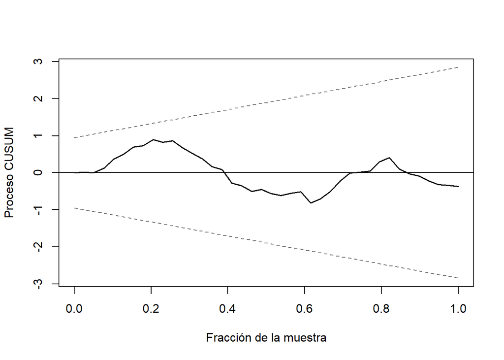

```r
# Límites críticos al 5%
limites_cusum <- boundary(
  efp_model,
  alpha = 0.05
)

# Mostrar gráfica
plot(
  efp_model,
  boundary = FALSE,
  main = "",
  xlab = "Fracción de la muestra",
  ylab = "Proceso CUSUM",
  col = "black",
  lwd = 1.5
)

lines(limites_cusum, col = "gray45", lty = 2, lwd = 1.2)
lines(-limites_cusum, col = "gray45", lty = 2, lwd = 1.2)
```

```r
# Guardar TIFF a 300 DPI
tiff(
  filename = "Figuras_Revista/Anexo_B1_CUSUM.tiff",
  width = 16,
  height = 10,
  units = "cm",
  res = 300,
  compression = "lzw",
  bg = "white"
)

par(
  mar = c(4.5, 4.5, 1.5, 1.5),
  cex.axis = 0.9,
  cex.lab = 1,
  las = 1
)

plot(
  efp_model,
  boundary = FALSE,
  main = "",
  xlab = "Fracción de la muestra",
  ylab = "Proceso CUSUM",
  col = "black",
  lwd = 1.5
)

lines(limites_cusum, col = "gray45", lty = 2, lwd = 1.2)
lines(-limites_cusum, col = "gray45", lty = 2, lwd = 1.2)

dev.off()
```

La gráfica evalúa la estabilidad global de los coeficientes del modelo a lo largo del tiempo.

No hay evidencia estadística de inestabilidad estructural en el modelo. Los coeficientes pueden considerarse estables durante todo el período analizado.

```r
# Estimar proceso MOSUM
efp_model2 <- efp(
  terc ~ terc_l1 + ln_per_capita +
    ln_per_capita_l1 + escolaridad,
  data = base_cusum,
  type = "Rec-MOSUM"
)

# Prueba estadística
sctest(efp_model2)
```

```
##
##  Recursive MOSUM test
##
## data:  efp_model2
## M = 0.89623, p-value = 0.3456
```

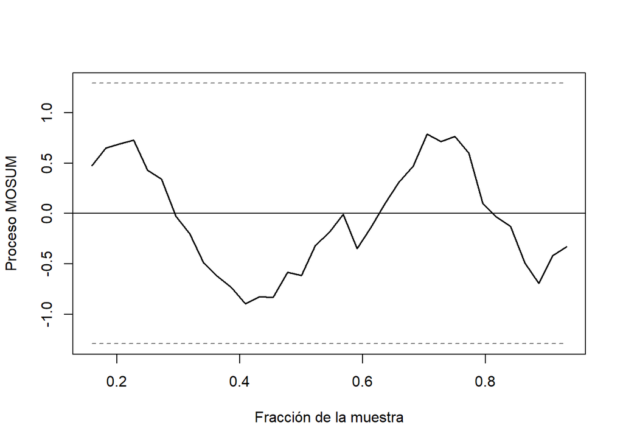

```r
# Límites críticos al 5%
limites_mosum <- boundary(
  efp_model2,
  alpha = 0.05
)

# Mostrar gráfica
plot(
  efp_model2,
  boundary = FALSE,
  main = "",
  xlab = "Fracción de la muestra",
  ylab = "Proceso MOSUM",
  col = "black",
  lwd = 1.5
)

lines(limites_mosum, col = "gray45", lty = 2, lwd = 1.2)
lines(-limites_mosum, col = "gray45", lty = 2, lwd = 1.2)
```

```r
# Guardar TIFF a 300 DPI
tiff(
  filename = "Figuras_Revista/Anexo_B2_MOSUM.tiff",
  width = 16,
  height = 10,
  units = "cm",
  res = 300,
  compression = "lzw",
  bg = "white"
)

par(
  mar = c(4.5, 4.5, 1.5, 1.5),
  cex.axis = 0.9,
  cex.lab = 1,
  las = 1
)

plot(
  efp_model2,
  boundary = FALSE,
  main = "",
  xlab = "Fracción de la muestra",
  ylab = "Proceso MOSUM",
  col = "black",
  lwd = 1.5
)

lines(limites_mosum, col = "gray45", lty = 2, lwd = 1.2)
lines(-limites_mosum, col = "gray45", lty = 2, lwd = 1.2)

dev.off()
```

La prueba MOSUM es similar al CUSUM, pero es más sensible a cambios locales o repentinos en ciertos periodos de la muestra.